# Final Project R

Maxim Clefos

ID: 43196

# Student Performance Data Set

https://archive.ics.uci.edu/ml/datasets/student+performance

*Citation:*

P. Cortez and A. Silva. Using Data Mining to Predict Secondary School Student Performance. In A. Brito and J. Teixeira Eds.,Proceedings of 5th FUture BUsiness TEChnology Conference (FUBUTEC 2008) pp. 5-12, Porto, Portugal, April, 2008, EUROSIS, ISBN 978-9077381-39-7.

#### $\color{blue}{\text{Data set information}}$

This data approach student achievement in secondary education of two Portuguese schools.

The data attributes include student grades, demographic, social and school related features) and it was collected by using school reports and questionnaires.

Two data sets are provided regarding the performance in two distinct subjects: Mathematics (mat) and Portuguese language (por).

#### $\color{blue}{\text{Variables information:}}$

1. *school* - student’s school (binary: ‘GP’ - Gabriel Pereira or ‘MS’ - Mousinho da Silveira)
2. *sex* - student’s sex (binary: ‘F’ - female or ‘M’ - male)
3. *age* - student’s age (numeric: from 15 to 22)
4. *address* - student’s home address type (binary: ‘U’ - urban or ‘R’ - rural)
5. *famsize* - family size (binary: ‘LE3’ - less or equal to 3 or ‘GT3’ - greater than 3)
6. *Pstatus* - parent’s cohabitation status (binary: ‘T’ - living together or ‘A’ - apart)
7. *Medu* - mother’s education (numeric: 0 - none, 1 - “primary education (4th grade)”, 2 - “ 5th to 9th grade“, 3 - “secondary education” or 4 - “ higher education")
8. *Fedu* - father’s education (numeric: 0 - none, 1 - primary education (4th grade), 2 - “ 5th to 9th grade“, 3 - “ secondary education” or 4 - “ higher education")
9. *Mjob* - mother’s job (nominal: ‘teacher’, ‘health’ care related, civil ‘services’ (e.g. administrative or police), ‘at_home’ or ‘other’)
10. *Fjob* - father’s job (nominal: ‘teacher’, ‘health’ care related, civil ‘services’ (e.g. administrative or police), ‘at_home’ or ‘other’)
11. *reason* - reason to choose this school (nominal: close to ‘home’, school ‘reputation’, ‘course’ preference or ‘other’)
12. *guardian* - student’s guardian (nominal: ‘mother’, ‘father’ or ‘other’)
13. *traveltime* - home to school travel time (numeric: 1 - less than 15 min., 2 - 15 to 30 min., 3 - 30 min. to 1 hour, or 4 - more than 1 hour)
14. *studytime* - weekly study time (numeric: 1 - less than 2 hours, 2 - 2 to 5 hours, 3 - 5 to 10 hours, or 4 - more than 10 hours)
15. *failures* - number of past class failures (numeric: n if between 1 and 3 , else 4)
16. *schoolsup* - extra educational support (binary: yes or no)
17. *famsup* - family educational support (binary: yes or no)
18. *paid* - extra paid classes within the course subject (Math or Portuguese) (binary: yes or no)
19. *activities* - extra-curricular activities (binary: yes or no)
20. *nursery* - attended nursery school (binary: yes or no)
21. *higher* - wants to take higher education (binary: yes or no)
22. *internet* - Internet access at home (binary: yes or no)
23. *romantic* - with a romantic relationship (binary: yes or no)
24. *famrel* - quality of family relationships (numeric: from 1 - very bad to 5 - excellent)
25. *freetime* - free time after school (numeric: from 1 - very low to 5 - very high)
26. *goout* - going out with friends (numeric: from 1 - very low to 5 - very high)
27. *Dalc* - workday alcohol consumption (numeric: from 1 - very low to 5 - very high)
28. *Walc* - weekend alcohol consumption (numeric: from 1 - very low to 5 - very high)
29. *health* - current health status (numeric: from 1 - very bad to 5 - very good)
30. *absences* - number of school absences (numeric: from 0 to 93)
31. *G1* - first period grade (numeric: from 0 to 20)
32. *G2* - second period grade (numeric: from 0 to 20)
33. *G3* - final grade (numeric: from 0 to 20, output target)

#### **$\color{red}{\text{Important note:}}$**

For the purpose of learning (also because it’s more unique), I decided not to use all the variables. I chose the ones that picked my curiosity. I don’t know what the result will be, so fingers crossed for a good one.

*Paper source for more details:* http://www3.dsi.uminho.pt/pcortez/student.pdf

From the paper provided above I know that:

1. *G1* and *G2* have a strong correlation to *G3*. This occurs because *G3* is the final year grade (issued at the 3rd period), while *G1* and *G2* correspond to the 1st and 2nd period grades.
2. The data can be used for regression, multiclassification or classification.

**I will use the data for classification (Pass/Fail)**

**I will not use all the variables, only:**

- *famsize* - family size (binary: ‘LE3’ - less or equal to 3 or ‘GT3’ - greater than 3)
- *Pstatus* - parent’s cohabitation status (binary: ‘T’ - living together or ‘A’ - apart)
- *Medu* - mother’s education (numeric: 0 - none, 1 - “primary education (4th grade)”, 2 - “ 5th to 9th grade“, 3 - “secondary education” or 4 - “ higher education")
- *Fedu* - father’s education (numeric: 0 - none, 1 - primary education (4th grade), 2 - “ 5th to 9th grade“, 3 - “ secondary education” or 4 - “ higher education")
- *Mjob* - mother’s job (nominal: ‘teacher’, ‘health’ care related, civil ‘services’ (e.g. administrative or police), ‘at_home’ or ‘other’)
- *Fjob* - father’s job (nominal: ‘teacher’, ‘health’ care related, civil ‘services’ (e.g. administrative or police), ‘at_home’ or ‘other’)
- *guardian* - student’s guardian (nominal: ‘mother’, ‘father’ or ‘other’)
- *famsup* - family educational support (binary: yes or no)
- *higher* - wants to take higher education (binary: yes or no)
- *internet* - Internet access at home (binary: yes or no)
- *Dalc* - workday alcohol consumption (numeric: from 1 - very low to 5 - very high)
- *Walc* - weekend alcohol consumption (numeric: from 1 - very low to 5 - very high)
- *absences* - number of school absences (numeric: from 0 to 93)
- *G3* - final grade (numeric: from 0 to 20, output target), which i will convert into Passed > 10; Failed < 11

**Libraries (not sure what I’ll need, so, I’m loading all of them)**

```r
library(AER)
library(dplyr)
```

```r
library(ggplot2)
library(ggthemes)
library(tseries)
library(corrgram)
library(corrplot)
library(caTools)
library(tidyr)
library(effsize)
library(car)
library(haven)
library(stats)
library(ggpubr)
library(scatterplot3d)
require(ggiraph)
require(ggiraphExtra)
require(plyr)
library(rsq)
library(robust)
library(qcc)
library(fitdistrplus)
library(psych)
library(lsr)
library(stats)
library(gridExtra)
library(fitdistrplus)
```

**Loading and checking the data**

```r
df_full <- read.csv("C:/Users/mkcle/Desktop/R-Course-HTML-Notes/R-for-Data-Science-and-Machine-Learning/Machine Learning with R/student-mat.csv", sep=';')

#View(df)

head(df_full, 3)
```

```
##   school sex age address famsize Pstatus Medu Fedu    Mjob    Fjob reason
## 1     GP   F  18       U     GT3       A    4    4 at_home teacher course
## 2     GP   F  17       U     GT3       T    1    1 at_home   other course
## 3     GP   F  15       U     LE3       T    1    1 at_home   other  other
##   guardian traveltime studytime failures schoolsup famsup paid activities
## 1   mother          2         2        0       yes     no   no         no
## 2   father          1         2        0        no    yes   no         no
## 3   mother          1         2        3       yes     no  yes         no
##   nursery higher internet romantic famrel freetime goout Dalc Walc health
## 1     yes    yes       no       no      4        3     4    1    1      3
## 2      no    yes      yes       no      5        3     3    1    1      3
## 3     yes    yes      yes       no      4        3     2    2    3      3
##   absences G1 G2 G3
## 1        6  5  6  6
## 2        4  5  5  6
## 3       10  7  8 10
```

Before converting variable *G3* into (Passed/Failed) I will take a look at it for any irregularities

```r
summary(df_full)
```

```
##     school              sex                 age         address
##  Length:395         Length:395         Min.   :15.0   Length:395
##  Class :character   Class :character   1st Qu.:16.0   Class :character
##  Mode  :character   Mode  :character   Median :17.0   Mode  :character
##                                        Mean   :16.7
##                                        3rd Qu.:18.0
##                                        Max.   :22.0
##    famsize            Pstatus               Medu            Fedu
##  Length:395         Length:395         Min.   :0.000   Min.   :0.000
##  Class :character   Class :character   1st Qu.:2.000   1st Qu.:2.000
##  Mode  :character   Mode  :character   Median :3.000   Median :2.000
##                                        Mean   :2.749   Mean   :2.522
##                                        3rd Qu.:4.000   3rd Qu.:3.000
##                                        Max.   :4.000   Max.   :4.000
##      Mjob               Fjob              reason            guardian
##  Length:395         Length:395         Length:395         Length:395
##  Class :character   Class :character   Class :character   Class :character
##  Mode  :character   Mode  :character   Mode  :character   Mode  :character
##
##
##
##    traveltime      studytime        failures       schoolsup
##  Min.   :1.000   Min.   :1.000   Min.   :0.0000   Length:395
##  1st Qu.:1.000   1st Qu.:1.000   1st Qu.:0.0000   Class :character
##  Median :1.000   Median :2.000   Median :0.0000   Mode  :character
##  Mean   :1.448   Mean   :2.035   Mean   :0.3342
##  3rd Qu.:2.000   3rd Qu.:2.000   3rd Qu.:0.0000
##  Max.   :4.000   Max.   :4.000   Max.   :3.0000
##     famsup              paid            activities          nursery
##  Length:395         Length:395         Length:395         Length:395
##  Class :character   Class :character   Class :character   Class :character
##  Mode  :character   Mode  :character   Mode  :character   Mode  :character
##
##
##
##     higher            internet           romantic             famrel
##  Length:395         Length:395         Length:395         Min.   :1.000
##  Class :character   Class :character   Class :character   1st Qu.:4.000
##  Mode  :character   Mode  :character   Mode  :character   Median :4.000
##                                                           Mean   :3.944
```

[output cut: 8 more lines]

```
##  Max.   :5.000   Max.   :5.000   Max.   :5.000   Max.   :5.000
##      health         absences            G1              G2
##  Min.   :1.000   Min.   : 0.000   Min.   : 3.00   Min.   : 0.00
##  1st Qu.:3.000   1st Qu.: 0.000   1st Qu.: 8.00   1st Qu.: 9.00
##  Median :4.000   Median : 4.000   Median :11.00   Median :11.00
##  Mean   :3.554   Mean   : 5.709   Mean   :10.91   Mean   :10.71
##  3rd Qu.:5.000   3rd Qu.: 8.000   3rd Qu.:13.00   3rd Qu.:13.00
##  Max.   :5.000   Max.   :75.000   Max.   :19.00   Max.   :19.00
##        G3
##  Min.   : 0.00
##  1st Qu.: 8.00
##  Median :11.00
##  Mean   :10.42
##  3rd Qu.:14.00
##  Max.   :20.00
```

Tking a closer look at the target variable

```r
table(df_full$G3)
```

```
##
##  0  4  5  6  7  8  9 10 11 12 13 14 15 16 17 18 19 20
## 38  1  7 15  9 32 28 56 47 31 31 27 33 16  6 12  5  1
```

There seem to be a lot of students(38) that go 0 as a final grade.

Pulling the samples with the students that have a 0 as the final grade

```r
g3_null <- filter(df_full, G3 == 0)
summary(g3_null)
```

```
##     school              sex                 age          address
##  Length:38          Length:38          Min.   :15.00   Length:38
##  Class :character   Class :character   1st Qu.:16.00   Class :character
##  Mode  :character   Mode  :character   Median :17.00   Mode  :character
##                                        Mean   :17.08
##                                        3rd Qu.:18.00
##                                        Max.   :19.00
##    famsize            Pstatus               Medu            Fedu
##  Length:38          Length:38          Min.   :1.000   Min.   :1.000
##  Class :character   Class :character   1st Qu.:2.000   1st Qu.:1.000
##  Mode  :character   Mode  :character   Median :2.000   Median :2.000
##                                        Mean   :2.316   Mean   :2.289
##                                        3rd Qu.:3.000   3rd Qu.:3.000
##                                        Max.   :4.000   Max.   :4.000
##      Mjob               Fjob              reason            guardian
##  Length:38          Length:38          Length:38          Length:38
##  Class :character   Class :character   Class :character   Class :character
##  Mode  :character   Mode  :character   Mode  :character   Mode  :character
##
##
##
##    traveltime      studytime        failures       schoolsup
##  Min.   :1.000   Min.   :1.000   Min.   :0.0000   Length:38
##  1st Qu.:1.000   1st Qu.:1.000   1st Qu.:0.0000   Class :character
##  Median :1.000   Median :2.000   Median :1.0000   Mode  :character
##  Mean   :1.605   Mean   :1.974   Mean   :0.9211
##  3rd Qu.:2.000   3rd Qu.:2.000   3rd Qu.:1.7500
##  Max.   :4.000   Max.   :4.000   Max.   :3.0000
##     famsup              paid            activities          nursery
##  Length:38          Length:38          Length:38          Length:38
##  Class :character   Class :character   Class :character   Class :character
##  Mode  :character   Mode  :character   Mode  :character   Mode  :character
##
##
##
##     higher            internet           romantic             famrel
##  Length:38          Length:38          Length:38          Min.   :1.000
##  Class :character   Class :character   Class :character   1st Qu.:3.000
##  Mode  :character   Mode  :character   Mode  :character   Median :4.000
##                                                           Mean   :3.842
##                                                           3rd Qu.:4.750
##                                                           Max.   :5.000
##     freetime         goout            Dalc            Walc
##  Min.   :1.000   Min.   :1.000   Min.   :1.000   Min.   :1.000
##  1st Qu.:3.000   1st Qu.:2.000   1st Qu.:1.000   1st Qu.:1.000
##  Median :3.000   Median :3.000   Median :1.000   Median :2.000
##  Mean   :3.132   Mean   :3.211   Mean   :1.342   Mean   :1.921
##  3rd Qu.:4.000   3rd Qu.:4.000   3rd Qu.:2.000   3rd Qu.:2.000
##  Max.   :5.000   Max.   :5.000   Max.   :3.000   Max.   :5.000
##      health         absences       G1               G2               G3
##  Min.   :1.000   Min.   :0   Min.   : 4.000   Min.   : 0.000   Min.   :0
##  1st Qu.:3.000   1st Qu.:0   1st Qu.: 6.000   1st Qu.: 0.000   1st Qu.:0
##  Median :4.000   Median :0   Median : 7.000   Median : 5.000   Median :0
##  Mean   :3.605   Mean   :0   Mean   : 7.526   Mean   : 4.658   Mean   :0
##  3rd Qu.:5.000   3rd Qu.:0   3rd Qu.: 9.000   3rd Qu.: 8.000   3rd Qu.:0
##  Max.   :5.000   Max.   :0   Max.   :12.000   Max.   :10.000   Max.   :0
```

I need to convert all categorical variables into factor to get a better summary Converting categorical variables into factors to get a better summary

```r
chr_vars <- dplyr::select(g3_null, -absences, -G1, -G2, -G3)

for(i in colnames(chr_vars)){
  chr_vars[,i] <- factor(chr_vars[,i])
}

summary(chr_vars)
```

```
##  school  sex    age     address famsize  Pstatus Medu   Fedu         Mjob
##  GP:34   F:23   15: 6   R:10    GT3:31   A: 2    1: 9   1:11   at_home : 9
##  MS: 4   M:15   16: 7   U:28    LE3: 7   T:36    2:14   2:13   health  : 2
##                 17: 8                            3: 9   3: 6   other   :14
##                 18:12                            4: 6   4: 8   services: 9
##                 19: 5                                          teacher : 4
##        Fjob           reason     guardian  traveltime studytime failures
##  at_home : 3   course    :19   father: 8   1:21       1:13      0:18
##  other   :21   home      :12   mother:25   2:12       2:16      1:10
##  services:11   other     : 1   other : 5   3: 4       3: 6      2: 5
##  teacher : 3   reputation: 6               4: 1       4: 3      3: 5
##
##  schoolsup famsup    paid    activities nursery  higher   internet romantic
##  no :37    no :15   no :30   no :17     no :10   no : 6   no : 8   no :18
##  yes: 1    yes:23   yes: 8   yes:21     yes:28   yes:32   yes:30   yes:20
##
##
##
##  famrel freetime goout Dalc   Walc   health
##  1: 1   1: 2     1:4   1:26   1:18   1: 2
##  2: 3   2: 4     2:9   2:11   2:12   2: 7
##  3: 7   3:21     3:8   3: 1   3: 3   3: 8
##  4:17   4: 9     4:9          4: 3   4: 8
##  5:10   5: 2     5:8          5: 2   5:13
```

```r
num_vars <- dplyr::select(g3_null, absences, G1, G2, G3)
summary(num_vars)
```

```
##     absences       G1               G2               G3
##  Min.   :0   Min.   : 4.000   Min.   : 0.000   Min.   :0
##  1st Qu.:0   1st Qu.: 6.000   1st Qu.: 0.000   1st Qu.:0
##  Median :0   Median : 7.000   Median : 5.000   Median :0
##  Mean   :0   Mean   : 7.526   Mean   : 4.658   Mean   :0
##  3rd Qu.:0   3rd Qu.: 9.000   3rd Qu.: 8.000   3rd Qu.:0
##  Max.   :0   Max.   :12.000   Max.   :10.000   Max.   :0
```

Based on the summary for those who got 0 as a final score we see that:

- 1. They had 0 absences (strange)
- 3. On average they go out less and drink lass on weekdays and weekends.

As mentioned above there seem to be some inconsistencies in the data. I will not remove any of the samples because I couldn’t find any concrete information on why there are so many zero values in the variable *G3*

#### $\color{blue}{\text{Create a data frame with the variables that are to be used}}$

```r
vars <- c("famsize", "Pstatus", "Medu", "Fedu", "Mjob", "Fjob", "guardian", "famsup", "higher", "internet", "Dalc", "Walc", "absences", "G3")
df <- df_full[, vars]
```

Check the new data frame

```r
#head(df, 3)
str(df)
```

```
## 'data.frame':    395 obs. of  14 variables:
##  $ famsize : chr  "GT3" "GT3" "LE3" "GT3" ...
##  $ Pstatus : chr  "A" "T" "T" "T" ...
##  $ Medu    : int  4 1 1 4 3 4 2 4 3 3 ...
##  $ Fedu    : int  4 1 1 2 3 3 2 4 2 4 ...
##  $ Mjob    : chr  "at_home" "at_home" "at_home" "health" ...
##  $ Fjob    : chr  "teacher" "other" "other" "services" ...
##  $ guardian: chr  "mother" "father" "mother" "mother" ...
##  $ famsup  : chr  "no" "yes" "no" "yes" ...
##  $ higher  : chr  "yes" "yes" "yes" "yes" ...
##  $ internet: chr  "no" "yes" "yes" "yes" ...
##  $ Dalc    : int  1 1 2 1 1 1 1 1 1 1 ...
##  $ Walc    : int  1 1 3 1 2 2 1 1 1 1 ...
##  $ absences: int  6 4 10 2 4 10 0 6 0 0 ...
##  $ G3      : int  6 6 10 15 10 15 11 6 19 15 ...
```

```r
df$G3 <- replace(df$G3, df$G3 <= 10, 0)
df$G3 <- replace(df$G3, df$G3 > 10, 1)
df$G3 <- factor(df$G3, levels = c(0, 1), labels = c("Falied", "Passed"))
table(df$G3)
```

```
##
## Falied Passed
##    186    209
```

Plot *G3*

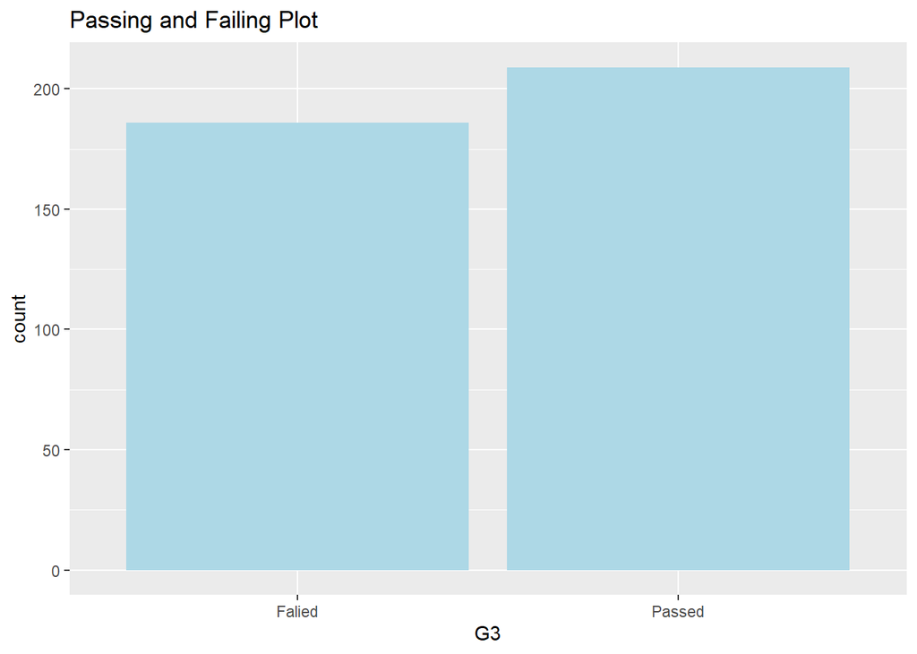

```r
ggplot(df, aes(x = G3)) + geom_bar(fill="lightblue") +
  ggtitle("Passing and Failing Plot")
```

**Perform Chi-square test goodness-of-fit and check the critical value**

- *HO: There is no significant difference in distribution between the groups that Failed or Passed*
- *Ha: There is a significant difference in distribution between the groups that Failed or Passed*

```r
# number of samples
N = length(df$G3)
print(paste0("Number of samples: ", N))
```

```
## [1] "Number of samples: 395"
```

```r
# test
chisq.test(table(df$G3), correct = F)
```

```
##
##  Chi-squared test for given probabilities
##
## data:  table(df$G3)
## X-squared = 1.3392, df = 1, p-value = 0.2472
```

```r
# critical value
print(paste0("Critical value: ", qchisq(.95, chisq.test(table(df$G3), correct = F)$parameter)))
```

```
## [1] "Critical value: 3.84145882069412"
```

Looks like both the p-value an the critical value indicate that we can accept H0: *X-squared(1, N = 395) = 1.34, p = 0.25*

Maening that there is no significant difference in distribution between the groups that Failed or Passed.

#### $\color{blue}{\text{Prepare the rest of the data}}$

**Things to do:**

- Check what the variable is labeled as, number of unique values
- Check distribution (Chi-S. goodness of fit) and plot.
- Perform Test of independence against G3 (Chi-Squared test of Ind. or Fisher exact test)

**A few helper functions**

Function to perform Chi-Squared goodness of fit test

```r
goodness_test <- function(df_var){
  result <- chisq.test(table(df_var), correct = F)
  # test info
  df <- result$parameter
  st <- round(result$statistic, digits = 3)
  n <- length(df_var)
  p <- round(result$p.value, digits = 3)

  # print test results
  print(result)
  print(paste0("Result: (df = ", df,", N=", n, ") = ", st, "; p = ", p))
  # print critical value
  print(paste0("Critical value: ",round(qchisq(.95, df), 3)))
}
```

Function to plot one categorical variable

```r
distribution_plot_1 <- function(df, var, var_name){
  ggplot(df, aes(x = {{var}})) + geom_bar(fill="lightblue") +
  ggtitle(paste0(var_name, " Distribution Plot"))
}
```

Function to plot two categorical variables

```r
distribution_plot_2 <- function(df, IV, DV, IV_name, DV_name){
  ggplot(df, aes(x = {{IV}}, fill = {{DV}})) +
  geom_bar(position = "dodge") +
  scale_fill_brewer() +
  ggtitle(paste0(IV_name, " and ", DV_name))
}
```

Function to test for independence (CHI-SQUARED TEST OF INDEPENDANCE)

- **H0: Variables are independent**
- **Ha: Variables are dependent**

```r
ind_chi <- function(IV, DV){
  result <- chisq.test(table(DV, IV))
  df <- result$parameter
  st <- result$statistic
  n <- length(DV)
  p <- round(result$p.value, digits = 3)
  to_print <- paste0("(",df,", N=", n, ") = ", st, "; p = ", p)

  print(table(DV, IV))
  cat("\n")
  print(result)
  cat("\n")
  print(to_print)
}
```

**Checking how many unique values each variable has**

```r
col.names <- colnames(df)
value.counts <- c()
for (i in colnames(df)){
  result <-length(table(df[i]))
  value.counts <- append(value.counts, result)
}

# create a dataframe with variables names and number of unique values
counts_df <- data.frame(col.names, value.counts)
counts_df
```

```
##    col.names value.counts
## 1    famsize            2
## 2    Pstatus            2
## 3       Medu            5
## 4       Fedu            5
## 5       Mjob            5
## 6       Fjob            5
## 7   guardian            3
## 8     famsup            2
## 9     higher            2
## 10  internet            2
## 11      Dalc            5
## 12      Walc            5
## 13  absences           34
## 14        G3            2
```

Looks like most of the variables have only a few unique values.

#### Looking at all the values individually

*$\color{blue}{\text{famsize}}$*

Convert into factor

```r
df$famsize <- factor(df$famsize)
```

Plot

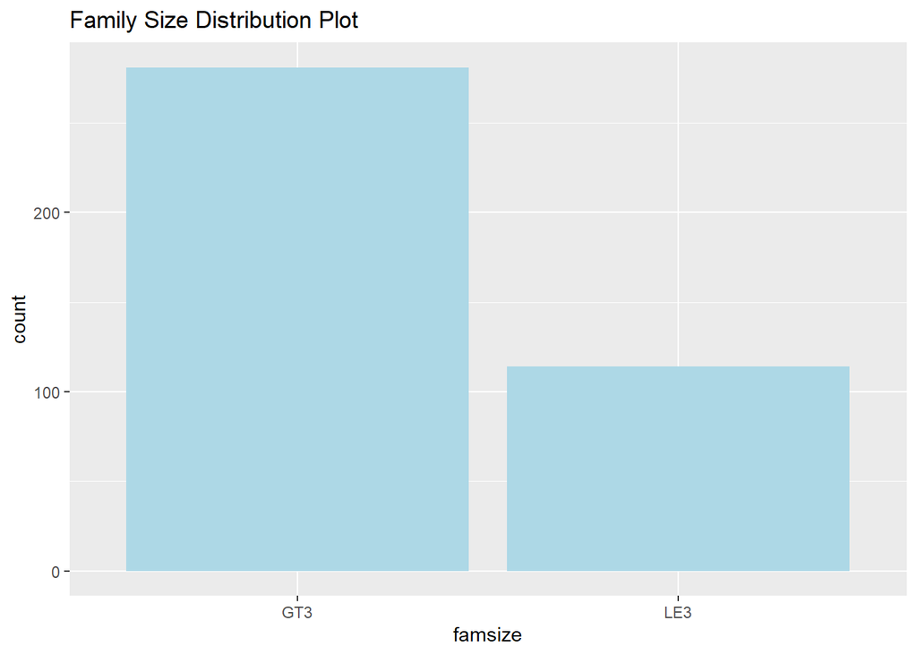

```r
distribution_plot_1(df, famsize, "Family Size")
```

```r
goodness_test(df$famsize)
```

```
##
##  Chi-squared test for given probabilities
##
## data:  table(df_var)
## X-squared = 70.605, df = 1, p-value < 2.2e-16
##
## [1] "Result: (df = 1, N=395) = 70.605; p = 0"
## [1] "Critical value: 3.841"
```

Plot *famsize* and *G3*

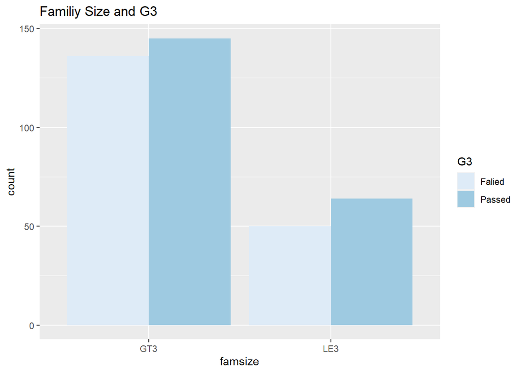

```r
distribution_plot_2(df, famsize, G3, "Familiy Size", "G3")
```

```r
ind_chi(df$famsize, df$G3)
```

```
##         IV
## DV       GT3 LE3
##   Falied 136  50
##   Passed 145  64
##
##
##  Pearson's Chi-squared test with Yates' continuity correction
##
## data:  table(DV, IV)
## X-squared = 0.50079, df = 1, p-value = 0.4792
##
##
## [1] "(1, N=395) = 0.500785424257049; p = 0.479"
```

Based on the result above we accept H0. Meaning that the variables are independent.

*$\color{blue}{\text{Pstatus}}$*

Convert into factor

```r
df$Pstatus <- factor(df$Pstatus, levels = c("A", "T"),
                     labels = c("Apart", "Together"))
```

Plot

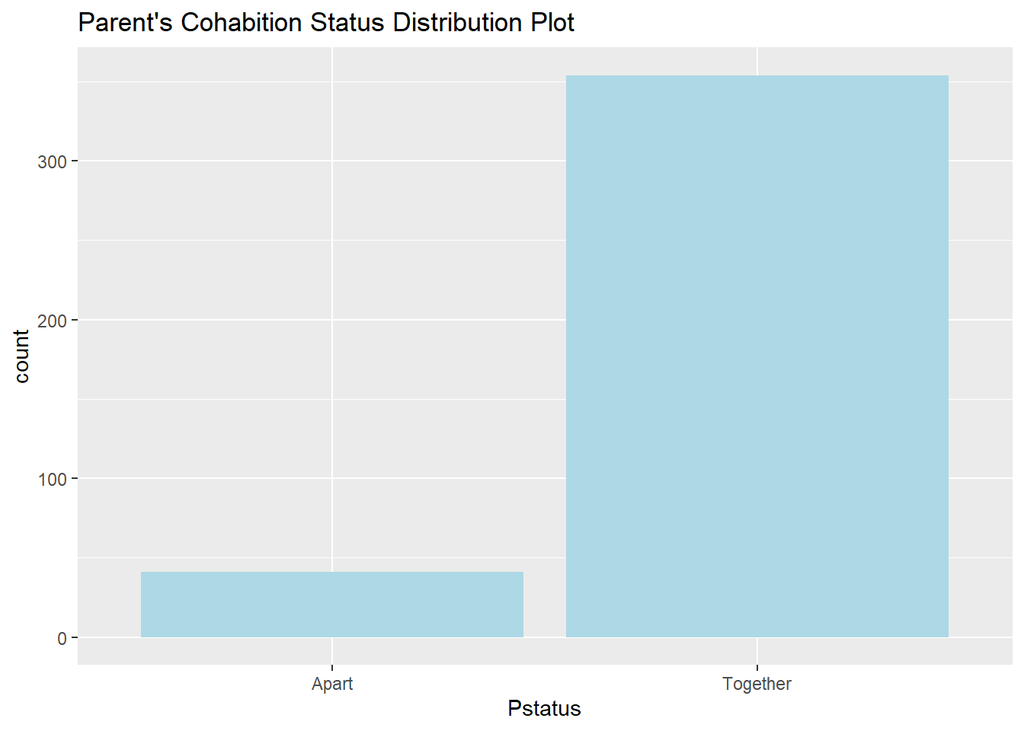

```r
distribution_plot_1(df, Pstatus, "Parent's Cohabition Status")
```

```r
goodness_test(df$Pstatus)
```

```
##
##  Chi-squared test for given probabilities
##
## data:  table(df_var)
## X-squared = 248.02, df = 1, p-value < 2.2e-16
##
## [1] "Result: (df = 1, N=395) = 248.023; p = 0"
## [1] "Critical value: 3.841"
```

Plot *Pstatuse* and *G3*

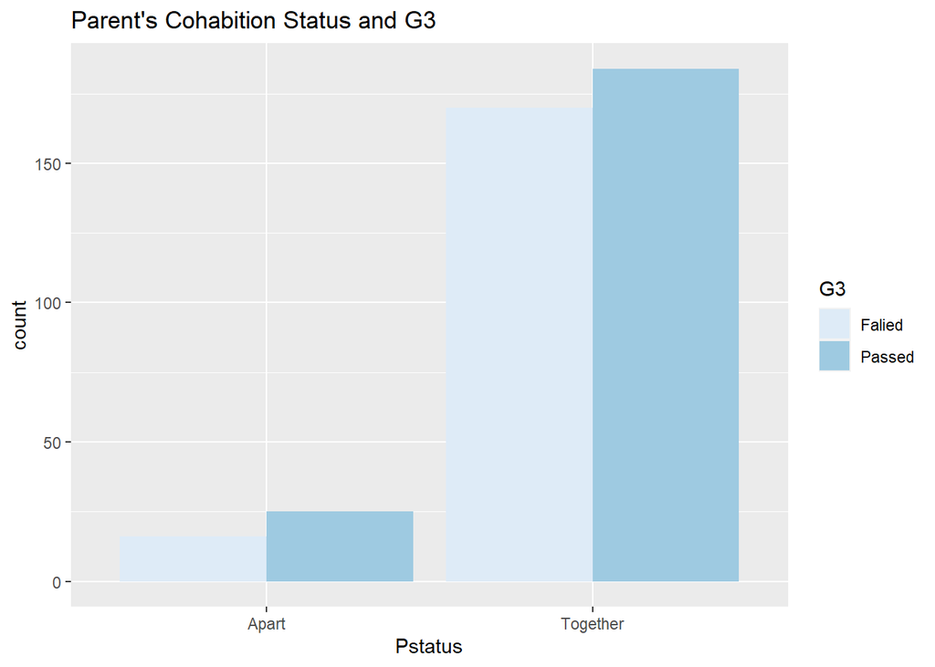

```r
distribution_plot_2(df, Pstatus, G3, "Parent's Cohabition Status", "G3")
```

```r
ind_chi(df$Pstatus, df$G3)
```

```
##         IV
## DV       Apart Together
##   Falied    16      170
##   Passed    25      184
##
##
##  Pearson's Chi-squared test with Yates' continuity correction
##
## data:  table(DV, IV)
## X-squared = 0.86024, df = 1, p-value = 0.3537
##
##
## [1] "(1, N=395) = 0.860244969102645; p = 0.354"
```

Based on the result above we accept H0. Meaning that the variables are independent.

*$\color{blue}{\text{Medu}}$* I will convert the variable into a factor. The variable contains information about the mothers education. I decided to specify the order from lowest level of education to highest. It is done based on the information in the source below:

https://www.acm.gov.pt/-/quais-os-niveis-de-educacao-escolar-obrigatoria-em-portugal-

1: No education -> none

2: Primary up to 4th grade: Primery_1

3: Primary up to 9th grade: Primery_2

4: Secondary up to 12 grade: Secondary

5: Higher Education: Higher

```r
table(df$Medu)
```

```
##
##   0   1   2   3   4
##   3  59 103  99 131
```

```r
edu_lvl <- c("None", "Primary_1", "Primary_2", "Secondary", "Higher")

df$Medu <- factor(df$Medu, levels = c(0, 1, 2, 3, 4),
                  labels = edu_lvl)
```

Check

```r
levels(df$Medu)
```

```
## [1] "None"      "Primary_1" "Primary_2" "Secondary" "Higher"
```

Plot

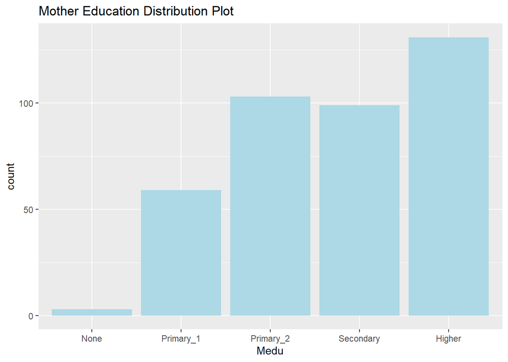

```r
distribution_plot_1(df, Medu, "Mother Education")
```

```r
goodness_test(df$Medu)
```

```
##
##  Chi-squared test for given probabilities
##
## data:  table(df_var)
## X-squared = 124.76, df = 4, p-value < 2.2e-16
##
## [1] "Result: (df = 4, N=395) = 124.759; p = 0"
## [1] "Critical value: 9.488"
```

Based on the results above we reject H0. Meaning that there is a significant difference in distribution between values in the variable

Plot *Medu* and *G3*

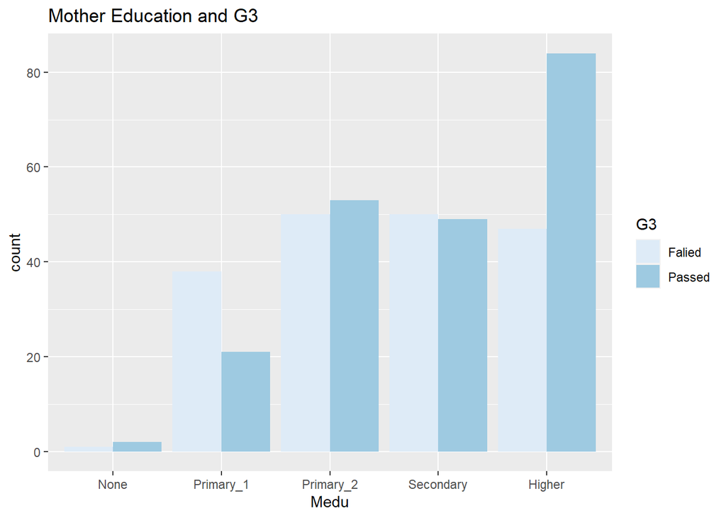

```r
distribution_plot_2(df, Medu, G3, "Mother Education", "G3")
```

```r
ind_chi(df$Medu, df$G3)
```

```
##         IV
## DV       None Primary_1 Primary_2 Secondary Higher
##   Falied    1        38        50        50     47
##   Passed    2        21        53        49     84
##
##
##  Pearson's Chi-squared test
##
## data:  table(DV, IV)
## X-squared = 14.489, df = 4, p-value = 0.005886
##
##
## [1] "(4, N=395) = 14.4893852461523; p = 0.006"
```

Looks like there some of the values in the table are below 6. For that reason Fishers Exact Test will be performed.

```r
fisher.test(table(df$G3, df$Medu))
```

```
##
##  Fisher's Exact Test for Count Data
##
## data:  table(df$G3, df$Medu)
## p-value = 0.003804
## alternative hypothesis: two.sided
```

Looks like both Chi-Square test of Independence and Fishers Exact Test suggest that we reject H0. Meaning that variables *Medu* and *G3* are not independent.

Affect size

```r
cramersV(table(df$G3, df$Medu))
```

```
## [1] 0.1915254
```

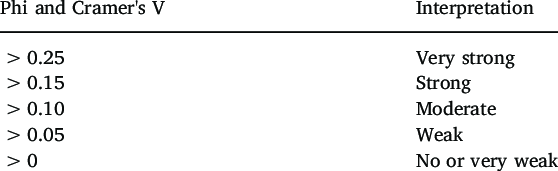

image

Based on the Cramer’s V result and the table shown above we see that there is a strong dependency between the variables.

*$\color{blue}{\text{Fedu}}$*

I will use the same information as used for *Medu* and convert the variable into a factor

```r
table(df$Fedu)
```

```
##
##   0   1   2   3   4
##   2  82 115 100  96
```

Convert into factor

```r
df$Fedu <- factor(df$Fedu, levels = c(0, 1, 2, 3, 4),
                  labels = edu_lvl)
```

Check

```r
table(df$Fedu)
```

```
##
##      None Primary_1 Primary_2 Secondary    Higher
##         2        82       115       100        96
```

Plot

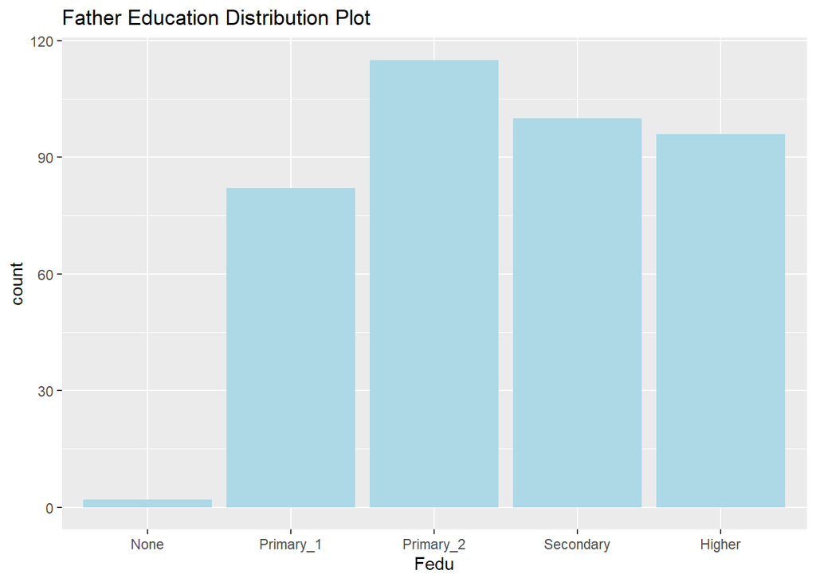

```r
distribution_plot_1(df, Fedu, "Father Education")
```

```r
goodness_test(df$Fedu)
```

```
##
##  Chi-squared test for given probabilities
##
## data:  table(df_var)
## X-squared = 100.81, df = 4, p-value < 2.2e-16
##
## [1] "Result: (df = 4, N=395) = 100.81; p = 0"
## [1] "Critical value: 9.488"
```

Based on the results above we reject H0. Meaning that there is a significant difference in distribution between values in the variable

Plot *Fedu* and *G3*

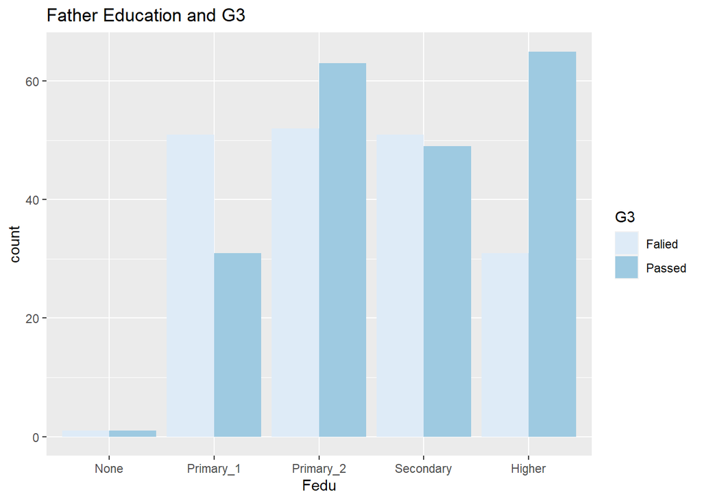

```r
distribution_plot_2(df, Fedu, G3, "Father Education", "G3")
```

```r
ind_chi(df$Fedu, df$G3)
```

```
##         IV
## DV       None Primary_1 Primary_2 Secondary Higher
##   Falied    1        51        52        51     31
##   Passed    1        31        63        49     65
##
##
##  Pearson's Chi-squared test
##
## data:  table(DV, IV)
## X-squared = 16.729, df = 4, p-value = 0.002182
##
##
## [1] "(4, N=395) = 16.7293694849056; p = 0.002"
```

Looks like there some of the values in the table are below 6. For that reason Fishers Exact Test will be performed.

```r
fisher.test(table(df$G3, df$Fedu))
```

```
##
##  Fisher's Exact Test for Count Data
##
## data:  table(df$G3, df$Fedu)
## p-value = 0.001105
## alternative hypothesis: two.sided
```

Looks like both Chi-Square test of Independence and Fishers Exact suggest that we reject H0. Meaning that variables *Fedu* and *G3* are not independent.

Effect size

```r
cramersV(table(df$G3, df$Fedu))
```

```
## [1] 0.205798
```

Based on Cramer’s V effect size we observ a strong dependency.

*$\color{blue}{\text{Mjob}}$*

Convert into factor

```r
df$Mjob <- factor(df$Mjob)
```

Plot

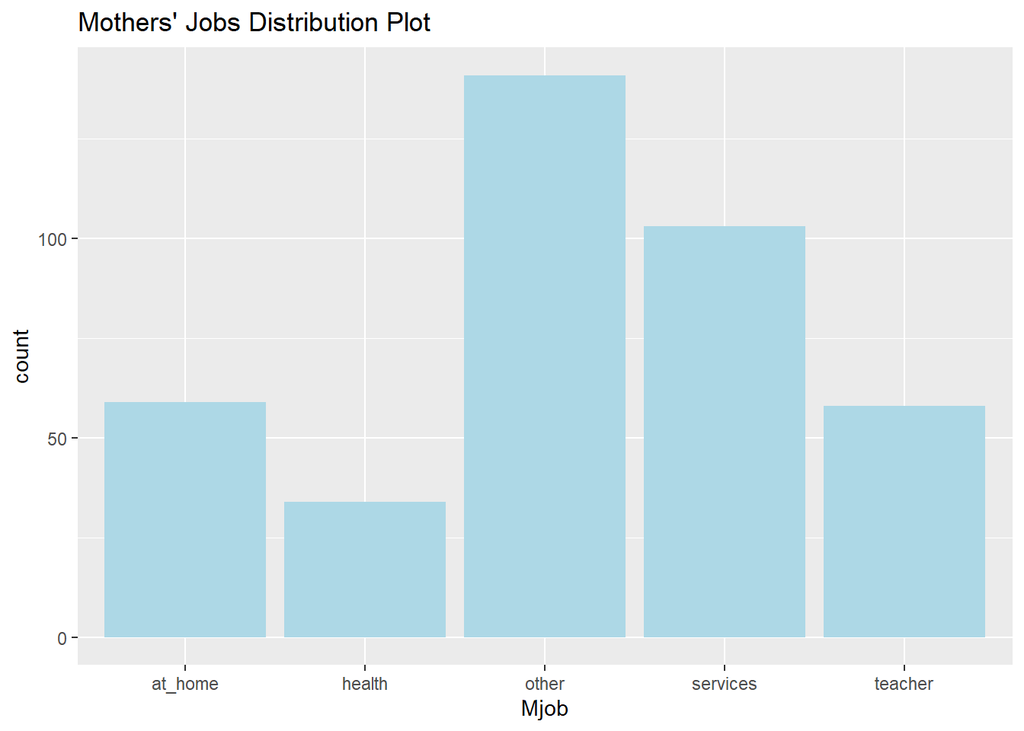

```r
distribution_plot_1(df, Mjob, "Mothers' Jobs")
```

```r
goodness_test(df$Mjob)
```

```
##
##  Chi-squared test for given probabilities
##
## data:  table(df_var)
## X-squared = 92.228, df = 4, p-value < 2.2e-16
##
## [1] "Result: (df = 4, N=395) = 92.228; p = 0"
## [1] "Critical value: 9.488"
```

We reject H0, meaning that there is a significant difference in distribution between the values in the variable.

Plot *Mjo*b and *G3*

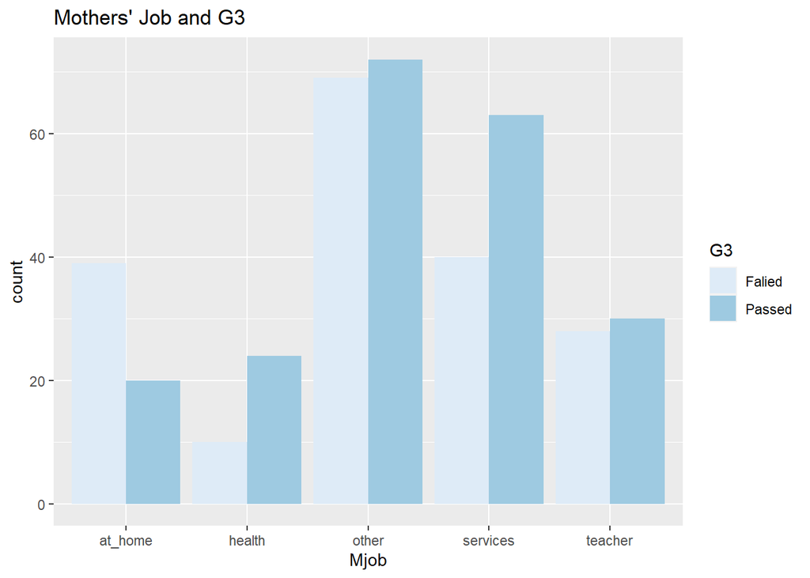

```r
distribution_plot_2(df, Mjob, G3, "Mothers' Job", "G3")
```

```r
ind_chi(df$Mjob, df$G3)
```

```
##         IV
## DV       at_home health other services teacher
##   Falied      39     10    69       40      28
##   Passed      20     24    72       63      30
##
##
##  Pearson's Chi-squared test
##
## data:  table(DV, IV)
## X-squared = 15.867, df = 4, p-value = 0.003203
##
##
## [1] "(4, N=395) = 15.8666225813285; p = 0.003"
```

Looks like we can reject H0. Meaning that variables *Mjob* and *G3* are not independent.

Affect size

```r
cramersV(table(df$G3, df$Mjob))
```

```
## [1] 0.2004212
```

Based on Cramer’s V effect size we observ a strong dependency.

*$\color{blue}{\text{Fjob}}$*

```r
table(df$Fjob)
```

```
##
##  at_home   health    other services  teacher
##       20       18      217      111       29
```

Convert to factor

```r
df$Fjob <- factor(df$Fjob)
table(df$Fjob)
```

```
##
##  at_home   health    other services  teacher
##       20       18      217      111       29
```

Plot

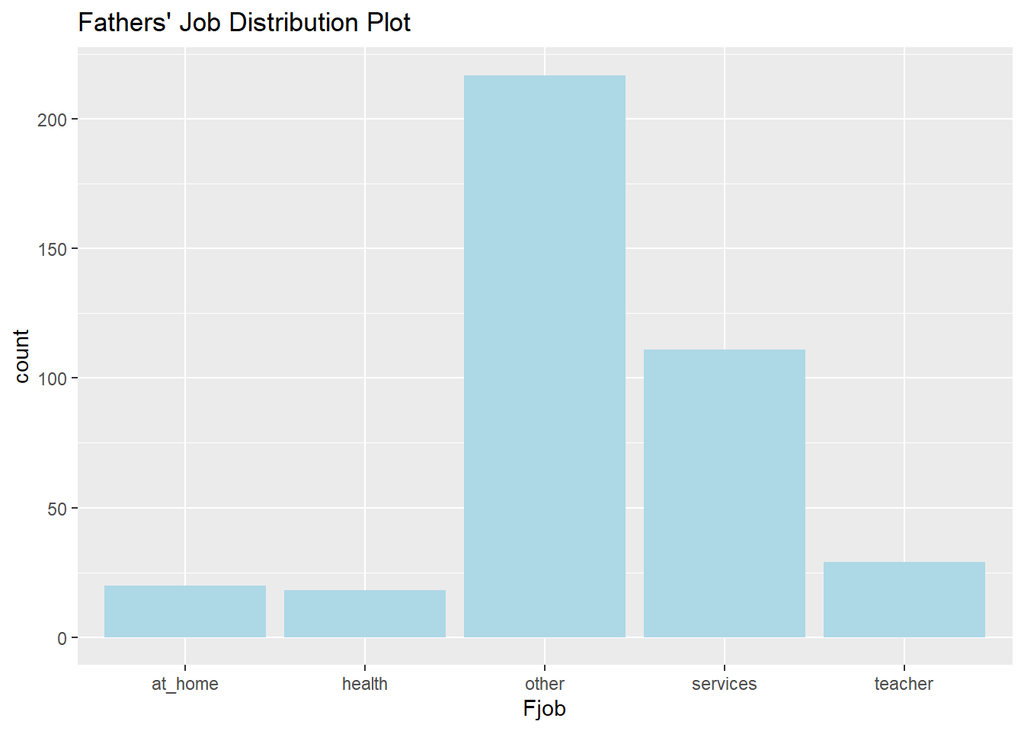

```r
distribution_plot_1(df, Fjob, "Fathers' Job")
```

```r
goodness_test(df$Fjob)
```

```
##
##  Chi-squared test for given probabilities
##
## data:  table(df_var)
## X-squared = 376.84, df = 4, p-value < 2.2e-16
##
## [1] "Result: (df = 4, N=395) = 376.835; p = 0"
## [1] "Critical value: 9.488"
```

We reject H0, meaning that there is a significant difference in distribution between the values in the variable.

Plot *Fjob* and *G3*

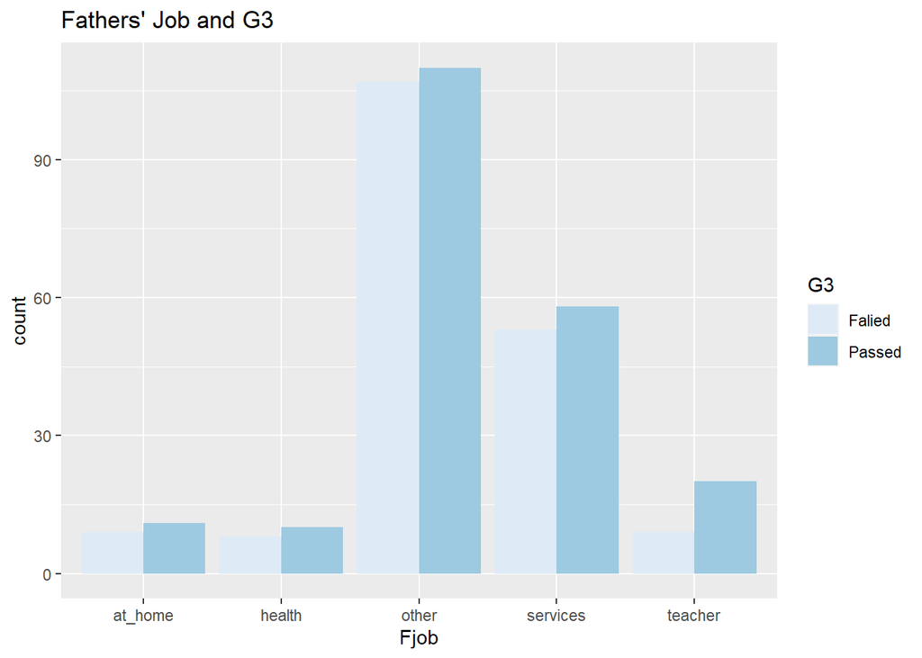

```r
distribution_plot_2(df, Fjob, G3, "Fathers' Job", "G3")
```

```r
ind_chi(df$Fjob, df$G3)
```

```
##         IV
## DV       at_home health other services teacher
##   Falied       9      8   107       53       9
##   Passed      11     10   110       58      20
##
##
##  Pearson's Chi-squared test
##
## data:  table(DV, IV)
## X-squared = 3.5341, df = 4, p-value = 0.4727
##
##
## [1] "(4, N=395) = 3.53407761618474; p = 0.473"
```

We can accept H0. Meaning that variables *Fjob* and *G3* are independent.

*$\color{blue}{\text{guardian}}$*

```r
table(df$guardian)
```

```
##
## father mother  other
##     90    273     32
```

Convert into factor

```r
df$guardian <- factor(df$guardian)
```

Plot

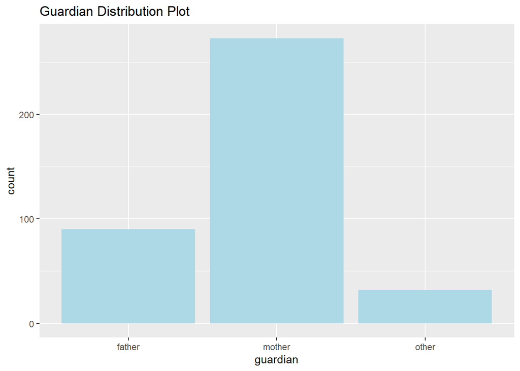

```r
distribution_plot_1(df, guardian, "Guardian")
```

```r
goodness_test(df$guardian)
```

```
##
##  Chi-squared test for given probabilities
##
## data:  table(df_var)
## X-squared = 240.34, df = 2, p-value < 2.2e-16
##
## [1] "Result: (df = 2, N=395) = 240.339; p = 0"
## [1] "Critical value: 5.991"
```

We reject H0, meaning that there is a significant difference in distribution between the values in the variable.

Plot *guardian* and *G3*

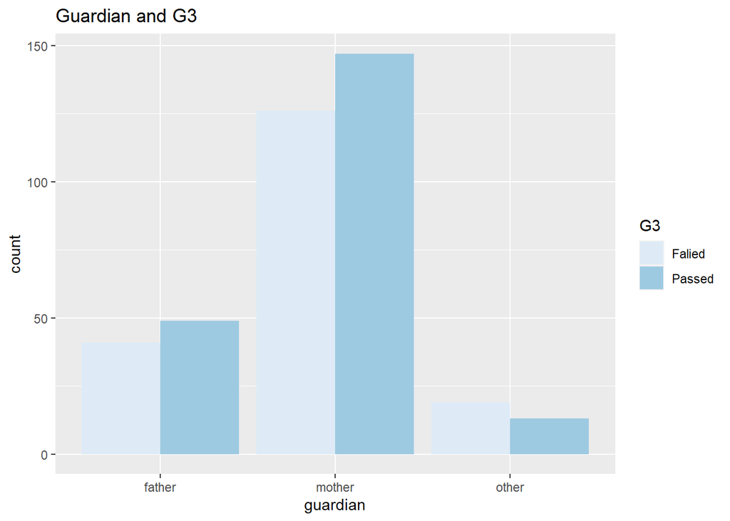

```r
distribution_plot_2(df, guardian, G3, "Guardian", "G3")
```

```r
ind_chi(df$guardian, df$G3)
```

```
##         IV
## DV       father mother other
##   Falied     41    126    19
##   Passed     49    147    13
##
##
##  Pearson's Chi-squared test
##
## data:  table(DV, IV)
## X-squared = 2.1194, df = 2, p-value = 0.3466
##
##
## [1] "(2, N=395) = 2.11944114785265; p = 0.347"
```

We can accept H0. Meaning that variables *guardian* and *G3* are independent.

*$\color{blue}{\text{famsup}}$*

```r
table(df$famsup)
```

```
##
##  no yes
## 153 242
```

Convert into factor

```r
df$famsup <- factor(df$famsup)
```

Plot

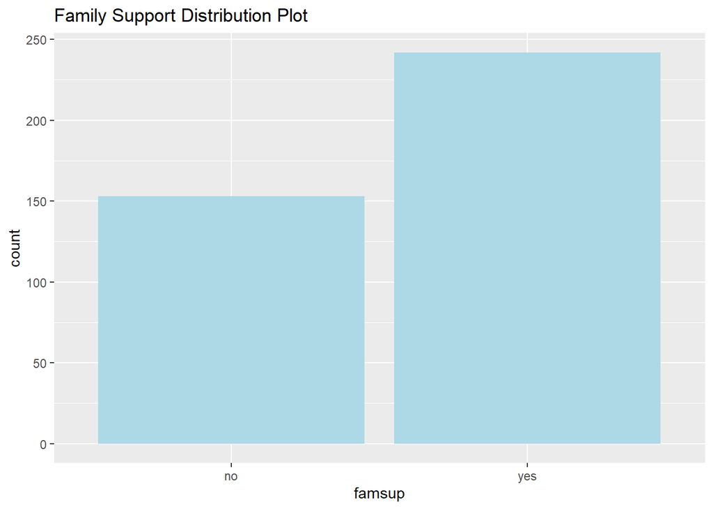

```r
distribution_plot_1(df, famsup, "Family Support")
```

```r
goodness_test(df$famsup)
```

```
##
##  Chi-squared test for given probabilities
##
## data:  table(df_var)
## X-squared = 20.053, df = 1, p-value = 7.532e-06
##
## [1] "Result: (df = 1, N=395) = 20.053; p = 0"
## [1] "Critical value: 3.841"
```

Based on the results above we reject H0. Meaning that there is a significant difference in distribution between values in the variable

Plot *famsup* and *G3*

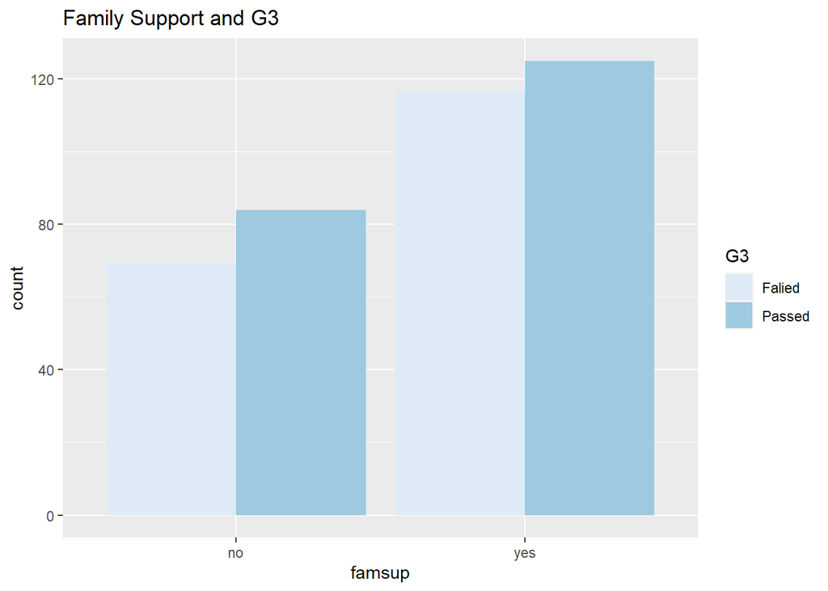

```r
distribution_plot_2(df, famsup, G3, "Family Support", "G3")
```

```r
ind_chi(df$famsup, df$G3)
```

```
##         IV
## DV        no yes
##   Falied  69 117
##   Passed  84 125
##
##
##  Pearson's Chi-squared test with Yates' continuity correction
##
## data:  table(DV, IV)
## X-squared = 0.27746, df = 1, p-value = 0.5984
##
##
## [1] "(1, N=395) = 0.277456701139229; p = 0.598"
```

We can accept H0. Meaning that variables *famsup* and *G3* are independent.

*$\color{blue}{\text{higher}}$*

```r
table(df$higher)
```

```
##
##  no yes
##  20 375
```

Convert into factor

```r
df$higher <- factor(df$higher)
```

Plot

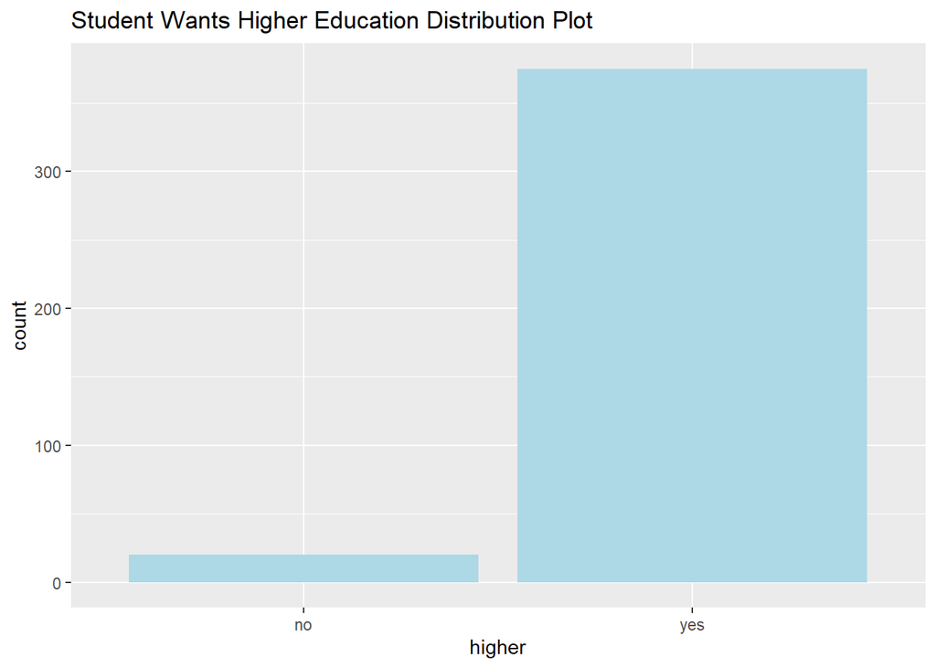

```r
distribution_plot_1(df, higher, "Student Wants Higher Education")
```

```r
goodness_test(df$higher)
```

```
##
##  Chi-squared test for given probabilities
##
## data:  table(df_var)
## X-squared = 319.05, df = 1, p-value < 2.2e-16
##
## [1] "Result: (df = 1, N=395) = 319.051; p = 0"
## [1] "Critical value: 3.841"
```

We can reject H0. Meaning that there is a significant difference in distribution between values in the variable

Plot *higher* and *G3*

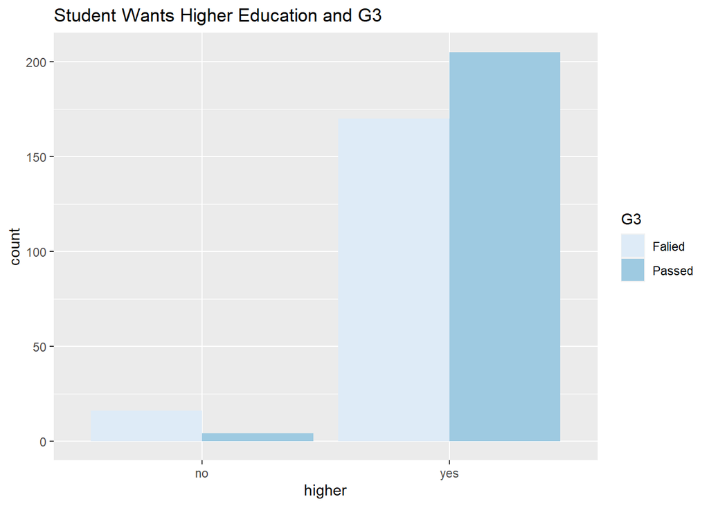

```r
distribution_plot_2(df, higher, G3, "Student Wants Higher Education", "G3")
```

```r
ind_chi(df$higher, df$G3)
```

```
##         IV
## DV        no yes
##   Falied  16 170
##   Passed   4 205
##
##
##  Pearson's Chi-squared test with Yates' continuity correction
##
## data:  table(DV, IV)
## X-squared = 7.8199, df = 1, p-value = 0.005167
##
##
## [1] "(1, N=395) = 7.81993952684742; p = 0.005"
```

Looks like one of the values in the table is below 6. For that reason Fishers Exact Test will be performed.

```r
fisher.test(table(df$G3, df$higher))
```

```
##
##  Fisher's Exact Test for Count Data
##
## data:  table(df$G3, df$higher)
## p-value = 0.002592
## alternative hypothesis: true odds ratio is not equal to 1
## 95 percent confidence interval:
##   1.512227 20.121321
## sample estimates:
## odds ratio
##   4.806383
```

Both test allow us the reject H0. Meaning that variables *higher* and *G3* are not independent.

Effect size

```r
cramersV(table(df$G3, df$higher))
```

```
## [1] 0.1407029
```

*$\color{blue}{\text{internet}}$*

```r
table(df$internet)
```

```
##
##  no yes
##  66 329
```

Convert into factor

```r
df$internet <- factor(df$internet)
```

Plot

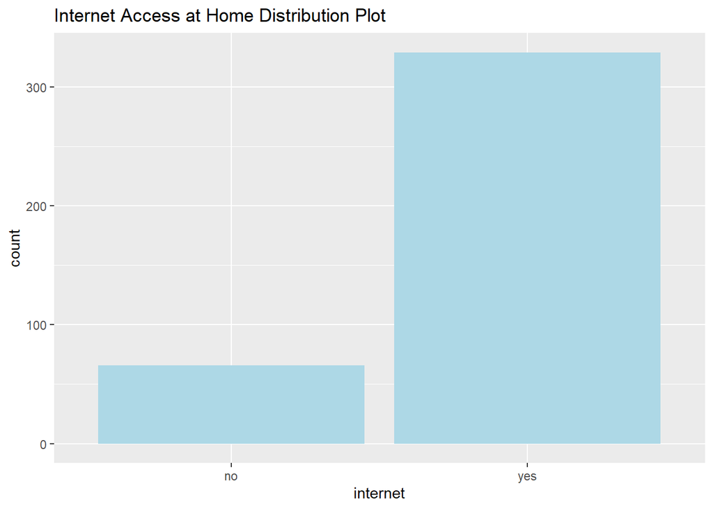

```r
distribution_plot_1(df, internet, "Internet Access at Home")
```

```r
goodness_test(df$internet)
```

```
##
##  Chi-squared test for given probabilities
##
## data:  table(df_var)
## X-squared = 175.11, df = 1, p-value < 2.2e-16
##
## [1] "Result: (df = 1, N=395) = 175.111; p = 0"
## [1] "Critical value: 3.841"
```

We can reject H0. Meaning that there is a significant difference in distribution between values in the variable

Plot *internet* and *G3*

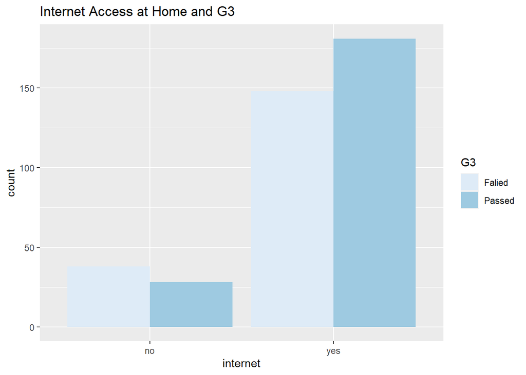

```r
distribution_plot_2(df, internet, G3, "Internet Access at Home", "G3")
```

```r
ind_chi(df$internet, df$G3)
```

```
##         IV
## DV        no yes
##   Falied  38 148
##   Passed  28 181
##
##
##  Pearson's Chi-squared test with Yates' continuity correction
##
## data:  table(DV, IV)
## X-squared = 3.0107, df = 1, p-value = 0.08272
##
##
## [1] "(1, N=395) = 3.01070195870767; p = 0.083"
```

We can accept H0. Meaning that variables *internet* and *G3* are independent.

*$\color{blue}{\text{Dalc}}$*

```r
table(df$Dalc)
```

```
##
##   1   2   3   4   5
## 276  75  26   9   9
```

I will convert it into a factor based on the information given about the data:

- 1: Very_low
- 2: Low
- 3: Medium
- 4: High
- 5: Very_high

```r
drinking_lvl <- c("Very_Low", "Low", "Medium", "High", "Very_High")

df$Dalc <- factor(df$Dalc, levels = c(1, 2, 3, 4, 5),
                  labels = drinking_lvl)

# check
table(df$Dalc)
```

```
##
##  Very_Low       Low    Medium      High Very_High
##       276        75        26         9         9
```

Plot

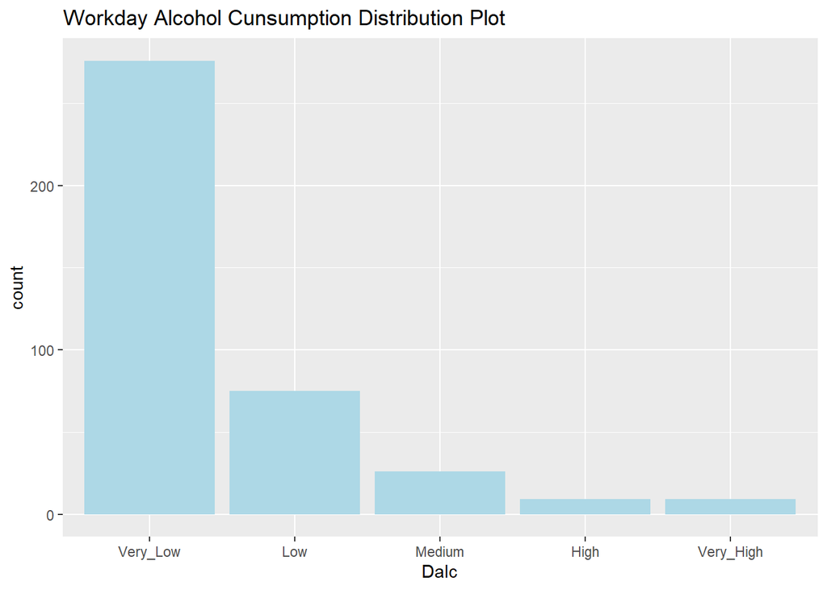

```r
distribution_plot_1(df, Dalc, "Workday Alcohol Cunsumption")
```

```r
goodness_test(df$Dalc)
```

```
##
##  Chi-squared test for given probabilities
##
## data:  table(df_var)
## X-squared = 651.06, df = 4, p-value < 2.2e-16
##
## [1] "Result: (df = 4, N=395) = 651.063; p = 0"
## [1] "Critical value: 9.488"
```

We can reject H0. Meaning that there is a significant difference in distribution between values in the variable

Plot *Dalc* and *G3*

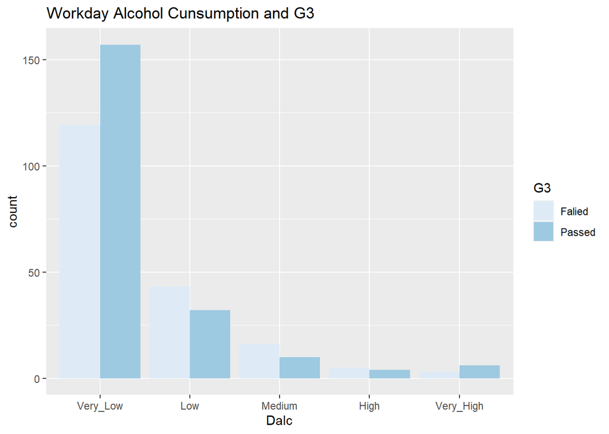

```r
distribution_plot_2(df, Dalc, G3, "Workday Alcohol Cunsumption", "G3")
```

```r
ind_chi(df$Dalc, df$G3)
```

```
##         IV
## DV       Very_Low Low Medium High Very_High
##   Falied      119  43     16    5         3
##   Passed      157  32     10    4         6
##
##
##  Pearson's Chi-squared test
##
## data:  table(DV, IV)
## X-squared = 8.0289, df = 4, p-value = 0.09052
##
##
## [1] "(4, N=395) = 8.02892530980853; p = 0.091"
```

Based on the table, looks like Fishers Exact Test will need to be performed

```r
fisher.test(table(df$G3, df$Dalc))
```

```
##
##  Fisher's Exact Test for Count Data
##
## data:  table(df$G3, df$Dalc)
## p-value = 0.08594
## alternative hypothesis: two.sided
```

Looks like both tests suggest that we can accept H0. Meaning that variables *Dalc* and *G3* are independent.

*$\color{blue}{\text{Walc}}$*

```r
table(df$Walc)
```

```
##
##   1   2   3   4   5
## 151  85  80  51  28
```

Same as variable *Dalc* I will convert *Walc*

```r
df$Walc <- factor(df$Walc, levels = c(1, 2, 3, 4, 5),
                  labels = drinking_lvl)

# check
table(df$Walc)
```

```
##
##  Very_Low       Low    Medium      High Very_High
##       151        85        80        51        28
```

plot

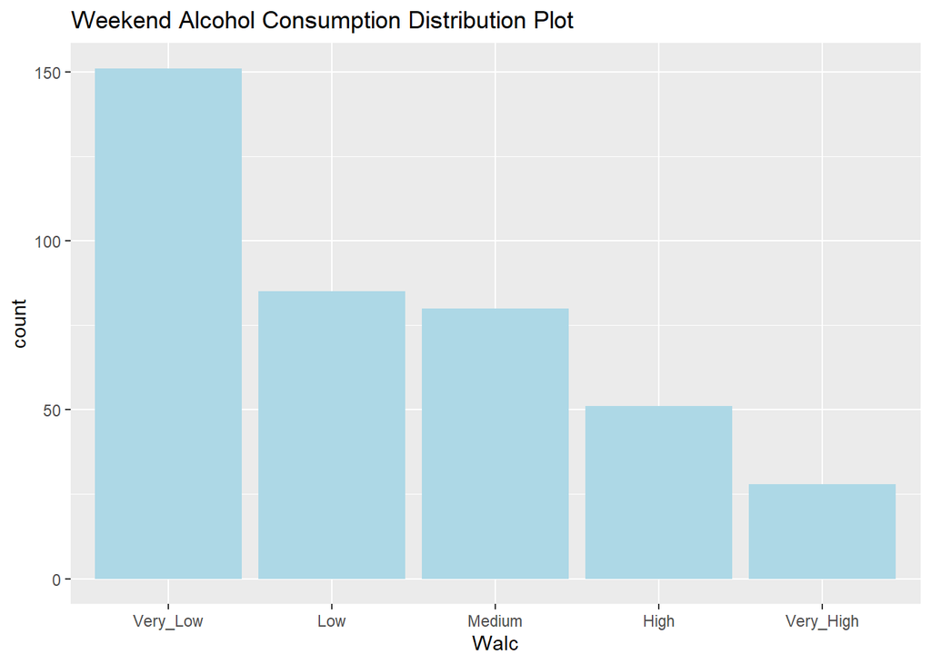

```r
distribution_plot_1(df, Walc, "Weekend Alcohol Consumption")
```

```r
goodness_test(df$Walc)
```

```
##
##  Chi-squared test for given probabilities
##
## data:  table(df_var)
## X-squared = 108.94, df = 4, p-value < 2.2e-16
##
## [1] "Result: (df = 4, N=395) = 108.937; p = 0"
## [1] "Critical value: 9.488"
```

We can reject H0. Meaning that there is a significant difference in distribution between values in the variable

Plot *Walc* and *G3*

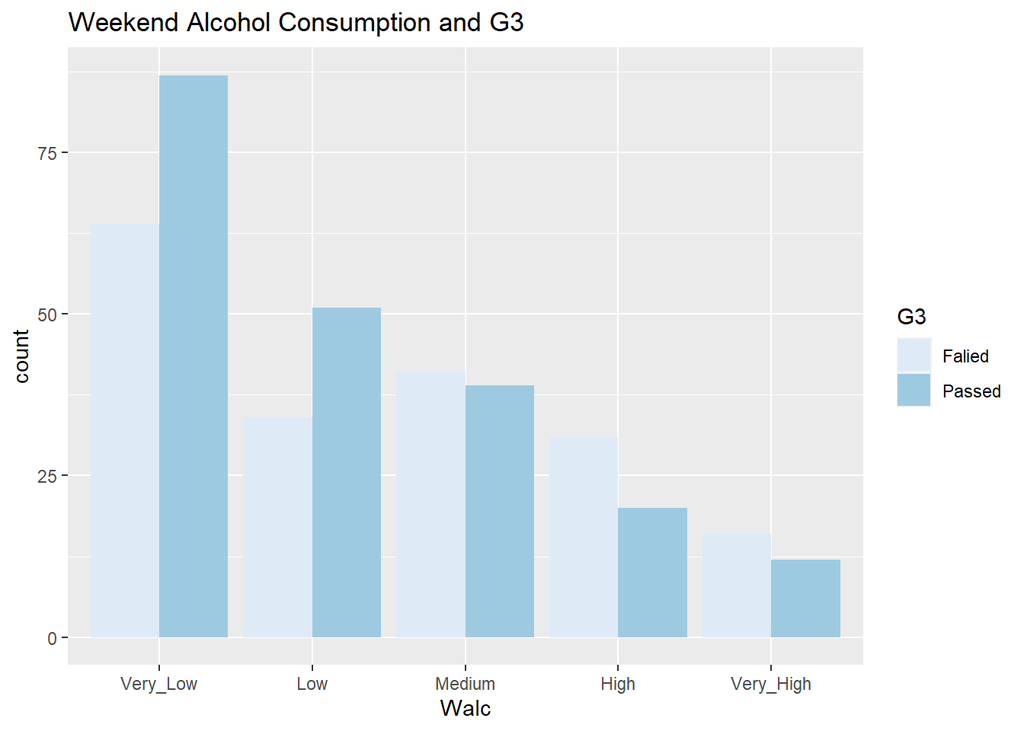

```r
distribution_plot_2(df, Walc, G3, "Weekend Alcohol Consumption", "G3")
```

```r
ind_chi(df$Walc, df$G3)
```

```
##         IV
## DV       Very_Low Low Medium High Very_High
##   Falied       64  34     41   31        16
##   Passed       87  51     39   20        12
##
##
##  Pearson's Chi-squared test
##
## data:  table(DV, IV)
## X-squared = 8.5872, df = 4, p-value = 0.07229
##
##
## [1] "(4, N=395) = 8.58716296698503; p = 0.072"
```

We can accept H0. Meaning that variables *Walc* and *G3* are independent.

*$\color{blue}{\text{absences}}$*

Summary

```r
psych::describe(df$absences)
```

```
##    vars   n mean sd median trimmed  mad min max range skew kurtosis  se
## X1    1 395 5.71  8      4    4.24 5.93   0  75    75 3.64    21.31 0.4
```

Based on the descriptions above, we see that the mean=5.71 is larger than the trimmed mean=4.24, meaining that the data might be skewed or have some ouliers in the upper tail.

Box plot

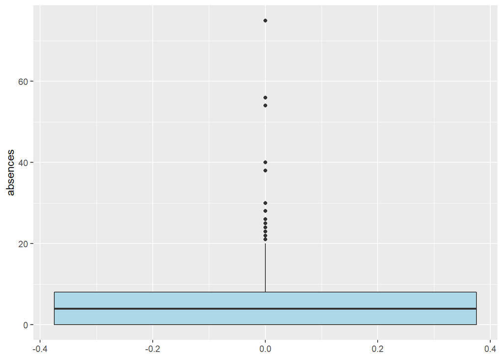

```r
ggplot(df, aes(y = absences)) +
  geom_boxplot(fill = "lightblue")
```

Histogram

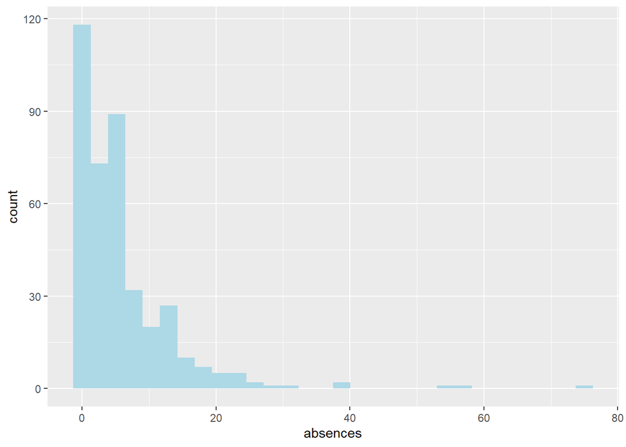

```r
ggplot(df, aes(absences)) +
  geom_histogram(fill = "lightblue", bins = 30)
```

Looks like the data is right skewed and has some outliers in the upper tail.

Plot *absences* and *G3* histogram

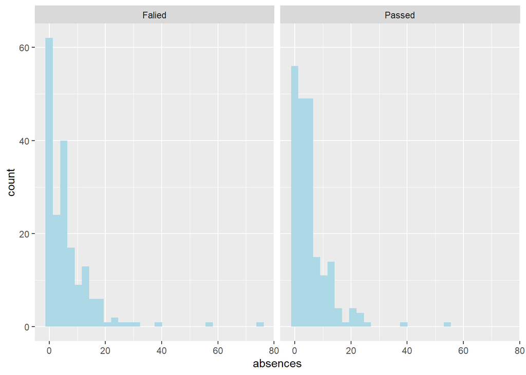

```r
ggplot(df, aes(absences, fill = G3)) +
  geom_histogram(fill = "lightblue", bins = 30) +
  facet_wrap(~G3)
```

Plot *absences* and *G3* box plot

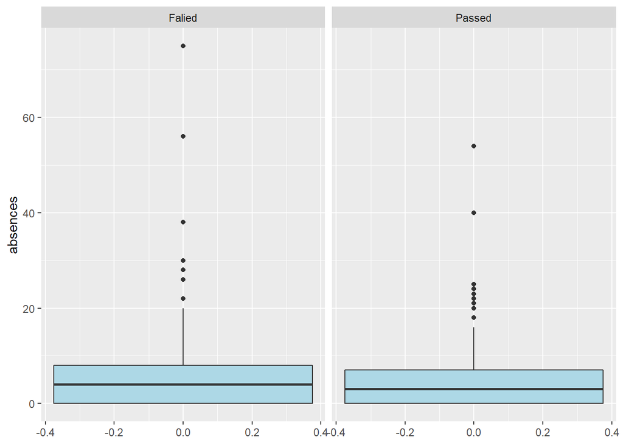

```r
ggplot(df, aes(y = absences, fill = G3)) +
  geom_boxplot(fill = "lightblue") +
  facet_wrap(~G3)
```

Looks like both groups (Failed and Passed) have some outliers in variable absences

Density plot

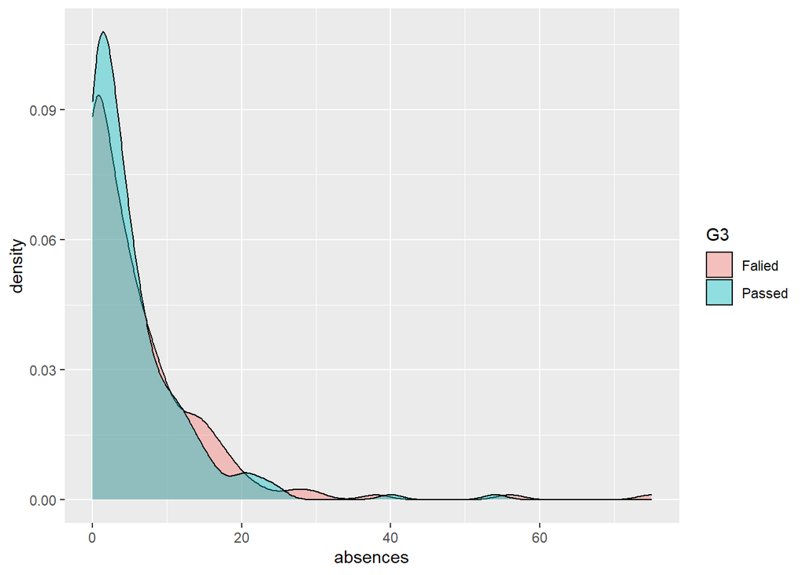

```r
ggplot(df, aes(absences, group = G3, fill = G3))+
  geom_density(alpha = 0.4)
```

Performing a Independent sample T-test:

- H0: The mean of absences of the group that failed does not differ from the mean of  
  absences of the group that passed
- Ha: The mean of absences of the group that failed is differ significantly from the mean of  
  absences of the group that passed.

ASSUMPTIONS:

Checking variance

- H0: Variances are equal
- Ha: variances are not equal

```r
leveneTest(absences ~ G3, df)
```

```
## Levene's Test for Homogeneity of Variance (center = median)
##        Df F value Pr(>F)
## group   1  2.4917 0.1152
##       393
```

Levene’s test give us a p-value of 0.11 so we can accept H0. Meaning that there is no significant difference between the variances.